# practical_exercise_5, Methods 3, 2021, autumn semester

Emma Olsen

27/10 - 2021

# Exercises and objectives

The objectives of the exercises of this assignment are based on: https://doi.org/10.1016/j.concog.2019.03.007

4. Download and organise the data from experiment 1
5. Use log-likelihood ratio tests to evaluate logistic regression models
6. Test linear hypotheses
7. Estimate psychometric functions for the Perceptual Awareness Scale and evaluate them

REMEMBER: In your report, make sure to include code that can reproduce the answers requested in the exercises below (**MAKE A KNITTED VERSION**)  
REMEMBER: This is part 2 of Assignment 2 and will be part of your final portfolio

# EXERCISE 4 - Download and organise the data from experiment 1

Go to https://osf.io/ecxsj/files/ and download the files associated with Experiment 1 (there should be 29).  
The data is associated with Experiment 1 of the article at the following DOI https://doi.org/10.1016/j.concog.2019.03.007

1. Put the data from all subjects into a single data frame - note that some of the subjects do not have the *seed* variable. For these subjects, add this variable and make in *NA* for all observations. (The *seed* variable will not be part of the analysis and is not an experimental variable)

```r
df <- read_bulk(
  directory = '/Users/emmaolsen/OneDrive - Aarhus Universitet/Methods3/github_methods_3/week_05/experiment_1',
  fun = read_csv
  )
```

[output not shown]

[output not shown]

[output not shown]

[output not shown]

[output not shown]

[output not shown]

[output not shown]

[output not shown]

[output not shown]

[output not shown]

[output not shown]

[output not shown]

[output not shown]

[output not shown]

[output not shown]

[output not shown]

[output not shown]

[output not shown]

[output not shown]

[output not shown]

[output not shown]

[output not shown]

[output not shown]

[output not shown]

[output not shown]

[output not shown]

[output not shown]

[output not shown]

[output not shown]

1. Factorise the variables that need factorising

```r
df$trial.type <- as.factor(df$trial.type)
df$pas <- as.factor(df$pas)
df$trial <- as.factor(df$trial)
df$cue <- as.factor(df$cue)
df$task <- as.factor(df$task)
df$target.type <- as.factor(df$target.type)
df$obj.resp <- as.factor(df$obj.resp)
df$subject <- as.factor(df$subject)
df$target.frames <- as.integer(df$target.frames)

ls.str(df)
```

```
## cue :  Factor w/ 36 levels "0","1","2","3",..: 1 1 1 1 1 1 1 1 1 1 ...
## even.digit :  num [1:25602] 8 4 2 8 6 6 6 4 4 8 ...
## File :  chr [1:25602] "001.csv" "001.csv" "001.csv" "001.csv" "001.csv" "001.csv" ...
## jitter.x :  num [1:25602] -0.431 -0.292 0.308 0.238 -0.427 ...
## jitter.y :  num [1:25602] -0.335 -0.182 0.406 0.175 -0.221 ...
## obj.resp :  Factor w/ 2 levels "e","o": 1 2 1 2 1 2 2 1 1 2 ...
## odd.digit :  num [1:25602] 9 5 5 9 3 9 3 5 7 9 ...
## pas :  Factor w/ 4 levels "1","2","3","4": 4 4 3 2 3 2 1 1 1 4 ...
## rt.obj :  num [1:25602] 1.418 0.86 0.746 1.676 0.847 ...
## rt.subj :  num [1:25602] 4.93 8.67 8.41 2.13 1.82 ...
## seed :  num [1:25602] 93764 93764 93764 93764 93764 ...
## subject :  Factor w/ 29 levels "001","002","003",..: 1 1 1 1 1 1 1 1 1 1 ...
## target.contrast :  num [1:25602] 0.1 0.1 0.1 0.1 0.1 0.1 0.1 0.1 0.1 0.1 ...
## target.frames :  int [1:25602] 9 8 7 6 5 4 3 2 1 9 ...
## target.type :  Factor w/ 2 levels "even","odd": 1 2 1 2 1 2 1 2 1 2 ...
## task :  Factor w/ 3 levels "pairs","quadruplet",..: 2 2 2 2 2 2 2 2 2 2 ...
## trial :  Factor w/ 864 levels "0","1","2","3",..: 1 2 3 4 5 6 7 8 9 10 ...
## trial.type :  Factor w/ 2 levels "experiment","practice": 2 2 2 2 2 2 2 2 2 2 ...
```

2. Remove the practice trials from the dataset (see the *trial.type* variable)

```r
df <- df %>% filter(trial.type=="experiment")
```

3. Create a *correct* variable

```r
df$correct <- ifelse((df$obj.resp == "o" & df$target.type=="odd") | (df$obj.resp == "e" & df$target.type=="even"), 1,0)
```

4. Describe how the *target.contrast* and *target.frames* variables differ compared to the data from part 1 of this assignment

*target.contrast*: in experiment 1, the experimenters didn’t adjust the target contrast to match the threshold of each individual. Therefore, the value of this variable is held constant at 0.1 for all subjects. They did, however, add staircasing trials in experiment 2, which is why we had different values of target.contrast for each subject in part 1 of this assignment (reflecting experiment 2)

*target.frame*: target.frame is an expression of SOA (stimulus onset asynchrony) - and takes value from 1-6 accordingly. As for *target.frames*, in experiment two, all participants saw the target frame for 3 frames, whereas in experiment 1, participants saw the target for 1-6 frames, equally distributed over participants. (1 Hz is 1 frame. A computer updates 60 Hz/sec. 1 frame equals 11.8 miliseconds)

```r
unique(df$target.frames)
```

```
## [1] 3 2 1 5 6 4
```

# EXERCISE 5 - Use log-likelihood ratio tests to evaluate logistic regression models

1. Do logistic regression - *correct* as the dependent variable and *target.frames* as the independent variable. (Make sure that you understand what *target.frames* encode). Create two models - a complete pooled model and a partial-pooling model. The partial-pooling model should include a subject-specific intercept.

```r
# Complete pooling model
m_complete <- glm(correct~target.frames, data = df, family=binomial(link=logit))

# Partial pooling model; modeling both an average and each level of the subjects
m_partial <- glmer(correct ~ target.frames + (1|subject),data=df,family=binomial(link=logit))
```

*So we wanna predict the probability of occurrence of an event based on several predictor variables*

1. the likelihood-function for logistic regression is: $L(p)={\displaystyle\prod_{i=1}^Np^{y_i}(1-p)^{(1-y_i)}}$ (Remember the probability mass function for the Bernoulli Distribution). Create a function that calculates the likelihood.
2. the log-likelihood-function for logistic regression is: $l(p) = {\displaystyle\sum_{i=1}^N}[y_i\ln{p}+(1-y_i)\ln{(1-p)}$. Create a function that calculates the log-likelihood
3. apply both functions to the complete pooling model you just created. Make sure that the log-likelihood matches what is returned from the *logLik* function for the complete pooled model. Does the likelihood-function return a value that is surprising? Why is the log-likelihood preferable when working with computers with limited precision?

```r
# Applying functions to models

likelihood_function(m_complete,df$correct) # 0
```

```
## [1] 0
```

```r
mylog_lik(m_complete,df$correct) # -10865.25
```

```
## [1] -10865.25
```

```r
logLik(m_complete) # -10865.25
```

```
## 'log Lik.' -10865.25 (df=2)
```

*The likelihood-function returns 0 which is not surprising. It represents the probability of observing the exact same values in the exact same order giving our model - this is very unlikely giving the many data points we have*

*The log-likelihood function *logLik* returns the same value (-10865.25) as my mylog_lik function outputted*

*The log-likelihood is preferable when working with computers with limited precision as it gives a higher number. It gives a value potentially really close to zero with a lot of decimals being 0 - a computer with low precision would just output 0, not showing any nuances.*

4. now show that the log-likelihood is a little off when applied to the partial pooling model - (the likelihood function is different for the multilevel function - see section 2.1 of https://www.researchgate.net/profile/Douglas-Bates/publication/2753537_Computational_Methods_for_Multilevel_Modelling/links/00b4953b4108d73427000000/Computational-Methods-for-Multilevel-Modelling.pdf if you are interested)

```r
mylog_lik(m_partial, df$correct) # -10565.53
```

```
## [1] -10565.53
```

```r
logLik(m_partial) # -10622.03
```

```
## 'log Lik.' -10622.03 (df=3)
```

*As can be seen in the output above, the two values differ slightly, showing that the log-likelihood is a little off.*

2. Use log-likelihood ratio tests to argue for the addition of predictor variables, start from the null model, `glm(correct ~ 1, 'binomial', data)`, then add subject-level intercepts, then add a group-level effect of *target.frames* and finally add subject-level slopes for *target.frames*. Also assess whether or not a correlation between the subject-level slopes and the subject-level intercepts should be included.

```r
anova(subject_lev,group_lev, groupsub_lev, nocormodel, null)
```

|  | npar | AIC | BIC | logLik | deviance | Chisq | Df | Pr(>Chisq) |
| --- | --- | --- | --- | --- | --- | --- | --- | --- |
| null | 1 | 26685.08 | 26693.21 | -13341.54 | 26683.08 | NA | NA | NA |
| subject_lev | 2 | 26319.10 | 26335.35 | -13157.55 | 26315.10 | 367.97976 | 1 | 5.153061e-82 |
| group_lev | 3 | 21250.06 | 21274.45 | -10622.03 | 21244.06 | 5071.03518 | 1 | 0.000000e+00 |
| nocormodel | 4 | 20928.58 | 20961.09 | -10460.29 | 20920.58 | 323.48672 | 1 | 2.520170e-72 |
| groupsub_lev | 5 | 20907.65 | 20948.29 | -10448.83 | 20897.65 | 22.92598 | 1 | 1.683609e-06 |

1. write a short methods section and a results section where you indicate which model you chose and the statistics relevant for that choice. Include a plot of the estimated group-level function with `xlim=c(0, 8)` that includes the estimated subject-specific functions.
2. also include in the results section whether the fit didn’t look good for any of the subjects. If so, identify those subjects in the report, and judge (no statistical test) whether their performance (accuracy) differed from that of the other subjects. Was their performance better than chance? (Use a statistical test this time) (50 %)

*Methods section: 4 different generalized linear mixed effects models (GLMM) were modeled, all of them with *correct* as target variable. the null model was also made:*

$\text{correct} \sim 1$ $\text{correct} \sim 1 + (1|\text{subject})$ $\text{correct} \sim \text{target.frames} + (1|\text{subject})$ $\text{correct} \sim \text{target.frames} + (1+\text{target.frames}||\text{subject})$

*Method*: *A likelihood ratio test was used to assess which predictor variables should be included in the model (comparing to the null model). In the log likelihood test, the null model was compared to three other models; one that included subject-level intercepts, one with a group-level effect of *target.frames* and finally add subject-level slopes for *target.frames*. It was also assessed whether or not a correlation between the subject-level slopes and the subject-level intercepts should be included.*

[output not shown]

```r
# Plot of the estimated group-level function with `xlim=c(0, 8)` that includes the estimated subject-specific functions.'

plot1 <- df %>%
  ggplot() +
  geom_smooth(aes(x = target.frames, y = fitted(groupsub_lev), color = "Partial Pooling model")) +
   geom_smooth(aes(x = target.frames, y = fitted(null), color = "Complete Pooling model")) +
   facet_wrap( ~ subject) +
   labs(title = "Plot 1: Estimated group-level function pr. subject") +
   labs(x = "x = target.frames (1:6)", y = "y = estimated functions (subject level)")
```

```r
fitted_values <- fitted(groupsub_lev) # extract fitted values for geom_line
df2 <- df %>%
  dplyr::select(-subject) # create data without subject to override facet_wrap in plot

df2$fitted_values <- fitted_values

plot2 <- ggplot(df, aes(x = target.frames, y = as.numeric(as.character(correct))))+
  geom_point(aes(y=as.numeric(as.character(correct))), color = "green", alpha = 0.05)+ # add alpha to be able to better access how many dots are clumped together
  geom_line(aes(target.frames, fitted_values), color = "blue") +
  #geom_line(data = data2, aes(target.frames, fitted_values), color = "red") +
  geom_smooth(data = df2, method = "glm", se = FALSE, method.args = list(family = "binomial"), color = "orange", size = 0.7) +
  facet_wrap(.~subject)+
  xlim(min = 0, max = 8)+
  labs(title = "Plot 2: Estimated group-level function pr. subject", y = "correct") +
  theme_bw()
```

```r
library(gridExtra)
```

[figure not shown]

```r
grid.arrange(plot1,plot2)
```

*Both plot 1 and 2 has target.frames on the x-axis*.

*In plot 2, the orange curve represents the estimate group.level functions, whereas the blue curve represents the estimated subject-specific functions. The green dots represent responses (they are layered on top of each other according to the corresponding target.frame from 1-6, which explains the different shades of green. Plot 2 indicates the same trend, i.e. that the fit generally suits most subjects fine but that subject-specific function for subject 24 deviates a lot from the estimated group-level function. The plot for subject 24 indicates that this participants had more incorrect trials at the higher target frames as compared to the rest of the subjects (as indicated by a darker green color of the dots at target frame 5-6 and accuracy at 0), which might explain the bad fit*

```r
# Making df subset with subject 24 only
sub24 <- df %>%
  filter(subject=="024")

# Making a one-sided t-test to assess if sub24 performed better than chance
t.test(as.numeric(as.character(sub24$correct)), mu=0.5, alternative = "greater") # testing whether mean performance is significantly different from 0.5 in a positive direction?
```

```
##
##  One Sample t-test
##
## data:  as.numeric(as.character(sub24$correct))
## t = 4.026, df = 873, p-value = 3.083e-05
## alternative hypothesis: true mean is greater than 0.5
## 95 percent confidence interval:
##  0.5398963       Inf
## sample estimates:
## mean of x
## 0.5675057
```

3. Now add *pas* to the group-level effects - if a log-likelihood ratio test justifies this, also add the interaction between *pas* and *target.frames* and check whether a log-likelihood ratio test justifies this

```r
# adding pas to the group-level effects
newmodel <- glmer(correct ~ target.frames+pas + (1+target.frames|subject), data=df, family=binomial(link = 'logit'), control = glmerControl(optimizer="bobyqa")) #adding pas as a fixed effect

# adding pas and interaction with target.frames to the group-level effects
model6 <- glmer(correct ~ target.frames*pas+ (1+target.frames|subject), data=df, family=binomial(link = 'logit'), control = glmerControl(optimizer="bobyqa")) # using an optimizer (bobyqa)


logLiks <- tibble("Model" = c("groupsub_lev", "newmodel", "model6"), "Log-likelihood" = c(logLik(groupsub_lev), logLik(newmodel), logLik(model6)))

logLiks
```

| Model | Log-likelihood |
| --- | --- |
| groupsub_lev | -10448.825 |
| newmodel | -9931.828 |
| model6 | -9742.039 |

2. plot the estimated group-level functions over `xlim=c(0, 8)` for each of the four PAS-ratings - add this plot to your report (see: 5.2.i) and add a description of your chosen model. Describe how *pas* affects accuracy together with target duration if at all. Also comment on the estimated functions’ behaviour at target.frame=0 - is that behaviour reasonable?

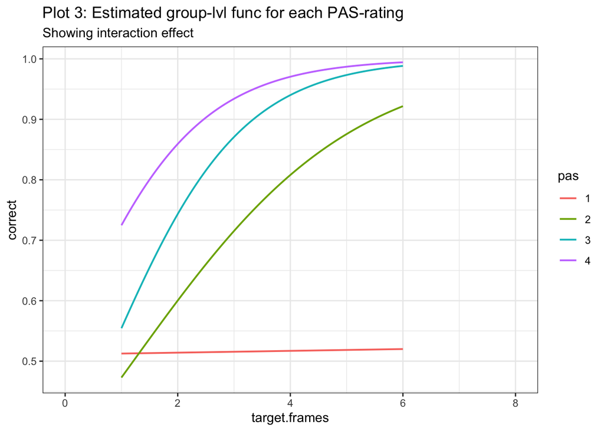

```r
plot3 <- ggplot(df, aes(x = target.frames, y = as.numeric(as.character(correct)), color = pas))+
  geom_smooth(method = "glm", se = FALSE, method.args = list(family = "binomial"), size = 0.7) +
  xlim(min = 0, max = 8)+
  labs(y = "correct") +
  labs(title = "Plot 3: Estimated group-lvl func for each PAS-rating",subtitle="Showing interaction effect") +
  theme_bw()

plot3
```

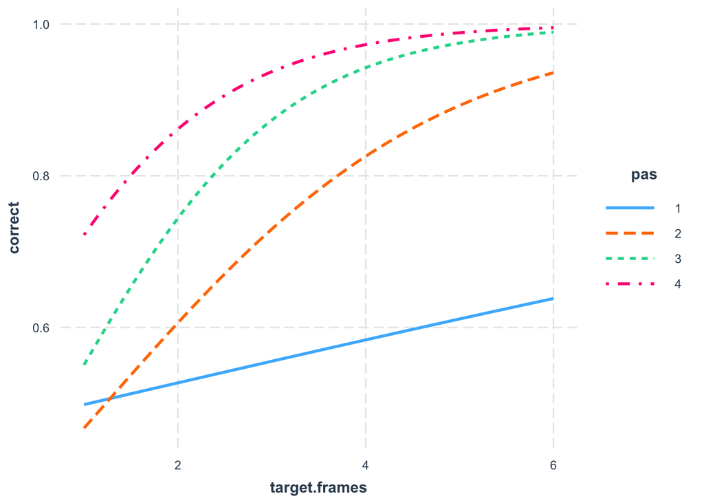

```r
interactions::interact_plot(model = model6, pred = "target.frames", modx = "pas") # visualizing the effects of pas and targetframes and their interactions
```

*Per increment of *target.frames*, accuracy increases across all 4 *pas* ratings except from *pas* = 1 that barely changes when *target.frames* changes. This makes sense as a *pas* rating of 1 refers to having no impression of the stimulus with all answers seen as mere guesses, and a change in *target.frames* would therefore not be expected to affect accuracy.*

*The steepness of the curves indicate that for *pas* = 2 and *pas* = 3, *target.frames* seems to influence accuracy a lot. This makes sense as they both refer to perceptual experiences associated with uncertainty of the content perceived*.

*pas* = 4 consistently has a higher accuracy, regardless of *target.frames*. *This makes sense as one would expect having a non-amnbiguous experience of the simulus and no doubts in one’s answer (which is was a *pas* rating of 4 represents) to result in a higher accuracy regardless of *target.frames*.*

*The plot reveals that at target.frames = 1, the baseline accuracy is actually slightly higher for *pas* = 1 ratings than *pas* = 2 ratings.*

# EXERCISE 6 - Test linear hypotheses

In this section we are going to test different hypotheses. We assume that we have already proved that more objective evidence (longer duration of stimuli) is sufficient to increase accuracy in and of itself and that more subjective evidence (higher PAS ratings) is also sufficient to increase accuracy in and of itself.

We want to test a hypothesis for each of the three neighbouring differences in PAS, i.e. the difference between 2 and 1, the difference between 3 and 2 and the difference between 4 and 3. More specifically, we want to test the hypothesis that accuracy increases faster with objective evidence if subjective evidence is higher at the same time, i.e. we want to test for an interaction.

1. Fit a model based on the following formula: `correct ~ pas * target.frames + (target.frames | subject))`

```r
# same model as earlier
model6 <- glmer(correct ~ target.frames*pas+ (1+target.frames|subject), data=df, family=binomial(link = 'logit'), control = glmerControl(optimizer="bobyqa"))
```

1. First, use `summary` (yes, you are allowed to!) to argue that accuracy increases faster with objective evidence for PAS 2 than for PAS 1.

```r
summary(model6)
```

```
## Generalized linear mixed model fit by maximum likelihood (Laplace
##   Approximation) [glmerMod]
##  Family: binomial  ( logit )
## Formula: correct ~ target.frames * pas + (1 + target.frames | subject)
##    Data: df
## Control: glmerControl(optimizer = "bobyqa")
##
##      AIC      BIC   logLik deviance df.resid
##  19506.1  19595.5  -9742.0  19484.1    25033
##
## Scaled residuals:
##      Min       1Q   Median       3Q      Max
## -19.0113   0.0537   0.1606   0.4849   1.4465
##
## Random effects:
##  Groups  Name          Variance Std.Dev. Corr
##  subject (Intercept)   0.03698  0.1923
##          target.frames 0.02058  0.1434   -0.76
## Number of obs: 25044, groups:  subject, 29
##
## Fixed effects:
##                    Estimate Std. Error z value Pr(>|z|)
## (Intercept)        -0.12163    0.06413  -1.897 0.057868 .
## target.frames       0.11480    0.03707   3.096 0.001959 **
## pas2               -0.57139    0.08937  -6.393 1.62e-10 ***
## pas3               -0.53851    0.13948  -3.861 0.000113 ***
## pas4                0.20146    0.25038   0.805 0.421050
## target.frames:pas2  0.44718    0.03473  12.877  < 2e-16 ***
## target.frames:pas3  0.74870    0.04593  16.301  < 2e-16 ***
## target.frames:pas4  0.75930    0.06845  11.092  < 2e-16 ***
## ---
## Signif. codes:  0 '***' 0.001 '**' 0.01 '*' 0.05 '.' 0.1 ' ' 1
##
## Correlation of Fixed Effects:
##             (Intr) trgt.f pas2   pas3   pas4   trg.:2 trg.:3
## target.frms -0.811
## pas2        -0.461  0.305
## pas3        -0.307  0.207  0.248
## pas4        -0.174  0.123  0.121  0.091
## trgt.frms:2  0.481 -0.428 -0.874 -0.245 -0.124
## trgt.frms:3  0.392 -0.358 -0.278 -0.891 -0.111  0.370
## trgt.frms:4  0.275 -0.260 -0.162 -0.121 -0.918  0.225  0.200
```

```r
# TO SUPPORT THE SUMMARY FUNCTION
# creating a table showing the percentile increase in accuracy for every fixed effect and interactions

estimates <- c(coef(summary(model6))[1:8]) # extract coefficients
increase_in_prob <- c(invlogit(estimates)) # invert logik
estimates_text <- c("intercept", "pas2", "pas3", "pas4", "target.frames", "target.frames:pas2", "target.frames:pas3", "target.frames:pas4")
probability_table <- as_tibble(cbind(estimates_text, increase_in_prob));print(probability_table)
```

[output not shown]

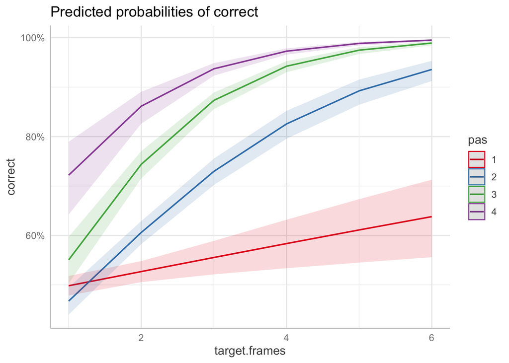

```r
# 2 DIFFERENT INTERACTION PLOTS SHOWING THE SAME THING
theme_set(theme_sjplot())
plot_model(model6, type = "pred", terms = c("target.frames", "pas"))
```

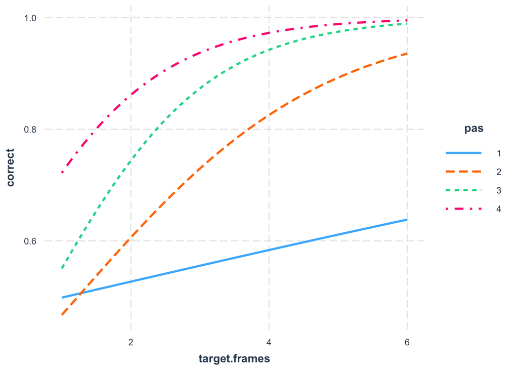

```r
interactions::interact_plot(model = model6, pred = "target.frames", modx = "pas")
```

*Both the summary output and our interaction plots indicate that accuracy increases faster with objective evidence for PAS 2 than for PAS 1. This supports our hypothesis that accuracy increases faster with objective evidence if subjecvtive evidence (PAS) is higher at the same time. The summary output shows a positive and significantinteraction term (target.frames:pas2) of 0.44718, p < .001.*

2. `summary` won’t allow you to test whether accuracy increases faster with objective evidence for PAS 3 than for PAS 2 (unless you use `relevel`, which you are not allowed to in this exercise). Instead, we’ll be using the function `glht` from the `multcomp` package
1. To redo the test in 6.1.i, you can create a *contrast* vector. This vector will have the length of the number of estimated group-level effects and any specific contrast you can think of can be specified using this. For redoing the test from 6.1.i, the code snippet below will do

For reference, below is a snippet from the summary output: target.frms -0.811  
pas2 -0.461 0.305  
pas3 -0.307 0.207 0.248  
pas4 -0.174 0.123 0.121 0.091  
trgt.frms:2 0.481 -0.428 -0.874 -0.245 -0.124  
trgt.frms:3 0.392 -0.358 -0.278 -0.891 -0.111 0.370  
trgt.frms:4 0.275 -0.260 -0.162 -0.121 -0.918 0.225 0.200

```r
# testing if accuracy does increase faster with objective evidence for "pas 2" than for "pas 1"
contrast.vector1 <- matrix(c(0, 0, 0, 0, 0, 1, 0, 0), nrow=1)
gh1 <- glht(model6, contrast.vector1)
print(summary(gh1))
```

```
##
##   Simultaneous Tests for General Linear Hypotheses
##
## Fit: glmer(formula = correct ~ target.frames * pas + (1 + target.frames |
##     subject), data = df, family = binomial(link = "logit"), control = glmerControl(optimizer = "bobyqa"))
##
## Linear Hypotheses:
##        Estimate Std. Error z value Pr(>|z|)
## 1 == 0  0.44718    0.03473   12.88   <2e-16 ***
## ---
## Signif. codes:  0 '***' 0.001 '**' 0.01 '*' 0.05 '.' 0.1 ' ' 1
## (Adjusted p values reported -- single-step method)
```

```r
invlogit(coef(summary(gh1))[1]) # probability of observing an increase in accuracy is 60.99695 % going from pas 1 to pas 2
```

```
##         1
## 0.6099695
```

2. Now test the hypothesis that accuracy increases faster with objective evidence for PAS 3 than for PAS 2.

```r
# testing if accuracy does increase faster with objective evidence for "pas 3" than for "pas 2"
contrast.vector2 <- matrix(c(0, 0, 0, 0, 0, -1, 1, 0), nrow=1)
gh2 <- glht(model6, contrast.vector2)
print(summary(gh2))
```

```
##
##   Simultaneous Tests for General Linear Hypotheses
##
## Fit: glmer(formula = correct ~ target.frames * pas + (1 + target.frames |
##     subject), data = df, family = binomial(link = "logit"), control = glmerControl(optimizer = "bobyqa"))
##
## Linear Hypotheses:
##        Estimate Std. Error z value Pr(>|z|)
## 1 == 0  0.30151    0.04621   6.525  6.8e-11 ***
## ---
## Signif. codes:  0 '***' 0.001 '**' 0.01 '*' 0.05 '.' 0.1 ' ' 1
## (Adjusted p values reported -- single-step method)
```

```r
invlogit(coef(summary(gh2))[1]) # probability of observing an increase in accuracy 57,48%  from pas 2 to pas 3
```

```
##         1
## 0.5748119
```

3. Also test the hypothesis that accuracy increases faster with objective evidence for PAS 4 than for PAS 3

```r
# testing if accuracy does increase faster with objective evidence for "pas 4" than for "pas 3"
contrast.vector3 <- matrix(c(0, 0, 0, 0, 0, 0, -1, 1), nrow=1)
gh3 <- glht(model6, contrast.vector3)
print(summary(gh3))
```

```
##
##   Simultaneous Tests for General Linear Hypotheses
##
## Fit: glmer(formula = correct ~ target.frames * pas + (1 + target.frames |
##     subject), data = df, family = binomial(link = "logit"), control = glmerControl(optimizer = "bobyqa"))
##
## Linear Hypotheses:
##        Estimate Std. Error z value Pr(>|z|)
## 1 == 0  0.01061    0.07441   0.143    0.887
## (Adjusted p values reported -- single-step method)
```

```r
invlogit(coef(summary(gh3))[1]) # probability of observing an increase in accuracy is 50,26%
```

```
##         1
## 0.5026524
```

3. Finally, test that whether the difference between PAS 2 and 1 (tested in 6.1.i) is greater than the difference between PAS 4 and 3 (tested in 6.2.iii)

### Snippet for 6.2.i

```r
## testing whether PAS 2 is different from PAS 1
contrast.vector <- matrix(c(0, 0, 0, 0, 0, 1, 0, 0), nrow=1) # 1 represents target.frames:pas2 from summary output
gh <- glht(model6, contrast.vector)
print(summary(gh)) # significant

## as another example, we could also test whether there is a difference in
## intercepts between PAS 2 and PAS 3
contrast.vector <- matrix(c(0, -1, 1, 0, 0, 0, 0, 0), nrow=1)
gh <- glht(pas.intact.tf.ranslopeint.with.corr, contrast.vector)
print(summary(gh))
```

# EXERCISE 7 - Estimate psychometric functions for the Perceptual Awareness Scale and evaluate them

We saw in 5.3 that the estimated functions went below chance at a target duration of 0 frames (0 ms). This does not seem reasonable, so we will be trying a different approach for fitting here.

We will fit the following function that results in a sigmoid, $f(x) = a + \frac {b - a} {1 + e^{\frac {c-x} {d}}}$

It has four parameters: *a*, which can be interpreted as the minimum accuracy level *b*, which can be interpreted as the maximum accuracy level *c*, which can be interpreted as the so-called inflexion point, i.e. where the derivative of the sigmoid reaches its maximum and *d*, which can be interpreted as the steepness at the inflexion point. (When *d* goes towards infinity, the slope goes towards a straight line, and when it goes towards 0, the slope goes towards a step function).

We can define a function of a residual sum of squares as below

```r
RSS <- function(dataset, par)
{
    ## "dataset" should be a data.frame containing the variables x (target.frames)
    ## and y (correct)

    ## "par" are our four parameters (a numeric vector)
    a <- par[1]
    b <- par[2]
    c <- par[3]
    d <- par[4]

    x <- dataset$x
    y <- dataset$y
    y.hat <- a+((b-a)/(1+exp((c-x)/d)))  #sigmoid funtion
    RSS <- sum((y - y.hat)^2)
    return(RSS)
}

# used later

y_hat_func <- function(a,b,c,d,x) {
  y.hat <- a+((b-a)/(1+exp((c-x)/d)))
  return(y.hat)
  }
```

1. Now, we will fit the sigmoid for the four PAS ratings for Subject 7
1. use the function `optim`. It returns a list that among other things contains the four estimated parameters. You should set the following arguments:

`par`: you can set *c* and *d* as 1. Find good choices for *a* and *b* yourself (and argue why they are appropriate) *a* can be interpreted as the minimum accuracy level *b* can be interpreted as the maximum accuracy level `fn`: which function to minimise? *In our case RSS.* `data`: the data frame with *x*, *target.frames*, and *y*, *correct* in it. *In our case df*. `method`: ‘L-BFGS-B’  
`lower`: lower bounds for the four parameters, (the lowest value they can take), you can set *c* and *d* as `-Inf`.Find good choices for *a* and *b* yourself (and argue why they are appropriate)  
`upper`: upper bounds for the four parameters, (the highest value they can take) can set *c* and *d* as `Inf`. Find good choices for *a* and *b* yourself (and argue why they are appropriate)

*First, I define the above arguments*:

```r
set.seed(1)

# Create subset dataframe
sub7 <- df %>%
  dplyr::filter(subject == "007") %>%
  dplyr::select(target.frames, correct, pas) %>%
  dplyr::rename(x = target.frames, y = correct)

lower <- c(0.5, 0.5, -Inf, -Inf)
upper <- c(1, 1, Inf, Inf)
par <- c(0.5, 1, 1, 1)
optim7 <- optim(data = sub7, fn = RSS, par = par, method = 'L-BFGS-B', lower = lower, upper = upper)


#Estimating the four parameters and making a tibble
parameters <- optim(data= sub7,par = par, fn= RSS, method= 'L-BFGS-B',lower =lower, upper =upper)
parameters_text<- c("a", "b", "c", "d")
parameters_values <- c(parameters[[1]][1], parameters[[1]][2], parameters[[1]][3], parameters[[1]][4])
parameter_tibble <- as.tibble(cbind(parameters_text, as.numeric(parameters_values)));print(parameter_tibble)
```

```
## # A tibble: 4 × 2
##   parameters_text V2
##   <chr>           <chr>
## 1 a               0.5
## 2 b               0.970758615177176
## 3 c               2.50896897656724
## 4 d               0.43104594644745
```

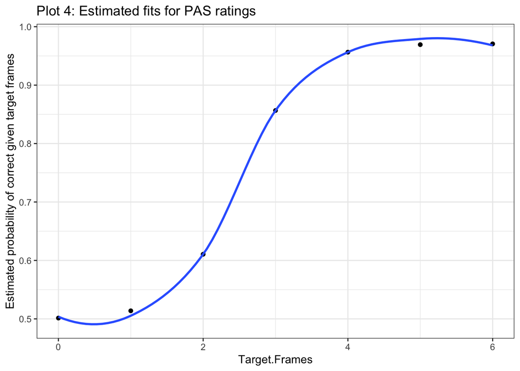

```r
sigfun7 <- function(x) {
  optim7$par[1] + ((optim7$par[2]-optim7$par[1])/(1+exp((optim7$par[3]-x)/optim7$par[4])))}


plot4 <- ggplot() +
  geom_point(aes(x = c(0:6), y = sigfun7 (0:6))) +
  geom_smooth(aes(x = c(0:6), y = sigfun7 (0:6)), se = FALSE) +
  labs(title = "Plot 4: Estimated fits for PAS ratings",
       x = "Target.Frames",
       y = "Estimated probability of correct given target frames") +
  theme_bw()

plot4
```

[figure not shown]

```r
#making pas numeric to be usable in optim:
sub7$x <- as.numeric(sub7$x)

#finding the a, b, c and d values estimated by optim which are to be used in the plot:
optim7pas <- optim(data = sub7, fn = RSS, par = par, method = 'L-BFGS-B', lower = c(0, 0, -Inf, -Inf), upper = c(1,1,Inf, Inf))

#generating a list of x-values, that can be used to make the new y's
x_list_p <- seq(1,4, 0.1) #now it is 4, since 4 pas ratings
#estimating the new y values based on x, the function and a, b, c and d:
y_list_p <- y_hat_func(optim7pas$par[1], optim7pas$par[2], optim7pas$par[3], optim7pas$par[4], x_list_p)

data_list_p <- data.frame(x_list_p, y_list_p)

pas_plot5 <- data_list_p %>%
  ggplot() +
  geom_point(aes(x_list_p, y_list_p)) +
  geom_smooth(aes(x_list_p, y_list_p, se = FALSE, colour = "red"))+
  ylim(0,1) +
  labs(title = "Sigmoid over the fitted pas ratings",
       y = "Estimated Correct Answers",
       x = "Pas"
       ) +
  theme_bw()
pas_plot5
```

2. Plot the fits for the PAS ratings on a single plot (for subject 7) `xlim=c(0, 8)`

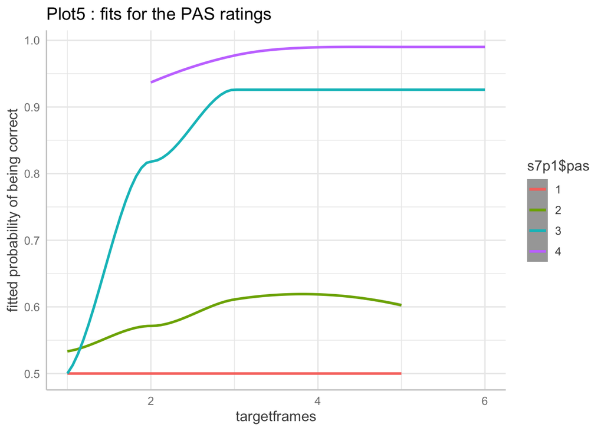

```r
# First, i make subset dfs for subject 7 dependent on pas

sub7$x <- as.numeric(sub7$x)
sub7$y <- as.numeric(sub7$y)
sub7$pas <- as.factor(sub7$pas)

# subject 7 pas 1
s7p1 <- sub7 %>%
  dplyr::filter(pas==1)

optim7_1 <- optim(data = s7p1, fn = RSS, par = par, method = 'L-BFGS-B', lower = c(0.5, 0.5, -Inf, -Inf), upper = c(1, 1, Inf, Inf))
fit7_1 <- optim7_1[[1]][1]+((optim7_1[[1]][2]-optim7_1[[1]][1])/(1+exp((optim7_1[[1]][3]-s7p1$x)/optim7_1[[1]][4])))


# subject 7 pas 2
s7p2 <- sub7 %>%
  dplyr::filter(pas==2)

optim7_2 <- optim(data = s7p2, fn = RSS, par = par, method = 'L-BFGS-B', lower = c(0.5, 0.5, -Inf, -Inf), upper = c(1, 1, Inf, Inf))
fit7_2<- optim7_2[[1]][1]+((optim7_2[[1]][2]-optim7_2[[1]][1])/(1+exp((optim7_2[[1]][3]-s7p2$x)/optim7_2[[1]][4])))


# subject 7 pas 3
s7p3 <- sub7 %>%
  dplyr::filter(pas==3)

optim7_3 <- optim(data = s7p3, fn = RSS, par = par, method = 'L-BFGS-B', lower = c(0.5, 0.5, -Inf, -Inf), upper = c(1, 1, Inf, Inf))
fit7_3<- optim7_3[[1]][1]+((optim7_3[[1]][2]-optim7_3[[1]][1])/(1+exp((optim7_3[[1]][3]-s7p3$x)/optim7_3[[1]][4])))

# subject 7 pas 4
s7p4 <- sub7 %>%
  dplyr::filter(pas==4)

optim7_4 <- optim(data = s7p4, fn = RSS, par = par, method = 'L-BFGS-B', lower = c(0.5, 0.5, -Inf, -Inf), upper = c(1, 1, Inf, Inf))
fit7_4 <- optim7_4[[1]][1]+((optim7_4[[1]][2]-optim7_4[[1]][1])/(1+exp((optim7_4[[1]][3]-s7p4$x)/optim7_4[[1]][4])))


sub7plot_6 <- ggplot()+
  geom_smooth((aes(x = s7p1$x, y = fit7_1,color=s7p1$pas)))+
  geom_smooth((aes(x = s7p2$x, y = fit7_2, color=s7p2$pas)))+
  geom_smooth((aes(x = s7p3$x, y = fit7_3, color=s7p3$pas)))+
  geom_smooth((aes(x = s7p4$x, y = fit7_4, color=s7p4$pas)))+
  labs(title = "Plot5 : fits for the PAS ratings")+
  labs(x = "targetframes", y = "fitted probability of being correct")

sub7plot_6
```

3. Create a similar plot for the PAS ratings on a single plot (for subject 7), but this time based on the model from 6.1 `xlim=c(0, 8)`

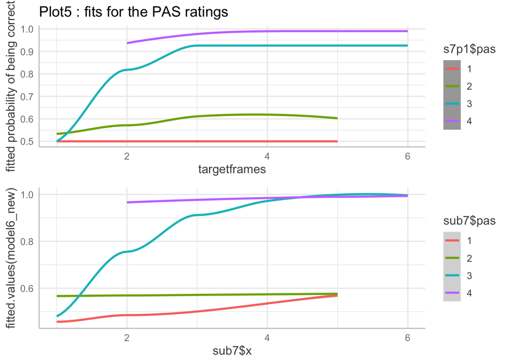

```r
model6_new <- glm(y ~ x*pas, data=sub7, family=binomial(link = 'logit'))

sub7_model6new <- ggplot()+
    geom_smooth((aes(x = sub7$x, y = fitted.values(model6_new),color=sub7$pas)))

pacman::p_load(gridExtra)
grid.arrange(sub7plot_6,sub7_model6new)
```

4. Comment on the differences between the fits - mention some advantages and disadvantages of each way

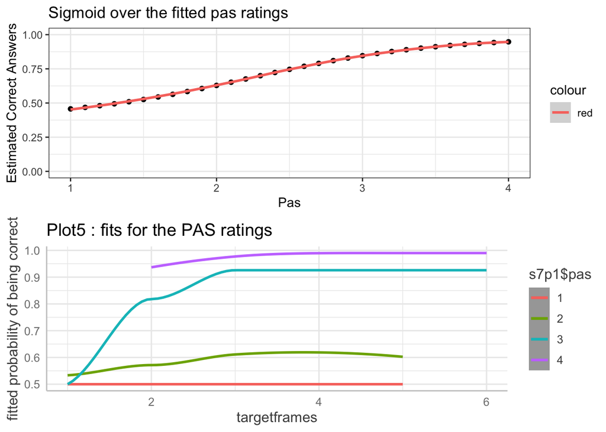

```r
library(gridExtra)
grid.arrange(pas_plot5,sub7plot_6)
```

2. Finally, estimate the parameters for all subjects and each of their four PAS ratings. Then plot the estimated function at the group-level by taking the mean for each of the four parameters, *a*, *b*, *c* and *d* across subjects. A function should be estimated for each PAS-rating (it should look somewhat similar to Fig. 3 from the article: https://doi.org/10.1016/j.concog.2019.03.007)

[figure not shown]

```
i. compare with the figure you made in 5.3.ii and comment on the differences between the fits - mention some advantages and disadvantages of both.
```

```r
par <- c(0.5, 1, 1, 1)
fn <- RSS
method = 'L-BFGS-B'
lower = c(0.5, 0.5, -Inf, -Inf)
upper = c(1, 1, Inf, Inf)
loop.df <- df %>%
  mutate(x = target.frames,
         y = correct,
         subject = as.numeric(subject),
         pas = as.numeric(pas))
n <- 0
output <- data.frame(subject=character(),
                 pas=integer(),
                 a=integer(),
                 b=integer(),
                 c=integer(),
                 d=integer())
for (i in 1:29) {

  for (n in 1:4) {
  subject.df <- loop.df %>%
    filter(subject == i & pas == n)

  optimated <- optim(par = par,
                     data = subject.df,
                     fn = fn,
                     method = method,
                     lower = lower,
                     upper =  upper)

  optimated.output <- data.frame(subject=i,
                 pas=n,
                 a=optimated$par[1],
                 b=optimated$par[2],
                 c=optimated$par[3],
                 d=optimated$par[4])

  output <- rbind(output, optimated.output)
}
}


summarised.output <- output %>%
  group_by(pas) %>%
  summarise(mean.a=mean(a), mean.b=mean(b), mean.c=mean(c), mean.d=mean(d))


# The formula for the sigmoid, with the optimized parameters that we found before
mean.fit.pas1 <- function(x) summarised.output$mean.a[1] + ((summarised.output$mean.b[1]-summarised.output$mean.a[1]) / (1+exp((summarised.output$mean.c[1]-x)/(summarised.output$mean.d[1]))))

mean.fit.pas2 <- function(x) summarised.output$mean.a[2] + ((summarised.output$mean.b[2]-summarised.output$mean.a[2]) / (2+exp((summarised.output$mean.c[2]-x)/(summarised.output$mean.d[2]))))

mean.fit.pas3 <- function(x) summarised.output$mean.a[3] + ((summarised.output$mean.b[3]-summarised.output$mean.a[3]) / (3+exp((summarised.output$mean.c[3]-x)/(summarised.output$mean.d[3]))))

mean.fit.pas4 <- function(x) summarised.output$mean.a[4] + ((summarised.output$mean.b[4]-summarised.output$mean.a[4]) / (4+exp((summarised.output$mean.c[4]-x)/(summarised.output$mean.d[4]))))


ggplot() +
  xlim(0, 8) +
  ylim(0, 1) +
  geom_function(aes(color = "pas1"), fun = mean.fit.pas1) +
  geom_function(aes(color = "pas2"), fun = mean.fit.pas2) +
  geom_function(aes(color = "pas3"), fun = mean.fit.pas3) +
  geom_function(aes(color = "pas4"), fun = mean.fit.pas4) +
  labs(x = "target.frames", y = "Likelihood of being correct", title = "Title") +
  theme_minimal()
```